# chap5_scatter_plots

### 5.12 Creating a balloon plot

ballon plot을 만들기 위해서는 `geom_point()`와 `scale_size_area()`를 조합하여 사용한다.

```r
cdat <- subset(countries, Year == 2009 &
                 Name %in% c("Canada", "Ireland","United Kingdom",
                             "United States", "New Zealand", "Iceland",
                             "Japan", "Luxembourg", "Netherlands",
                             "Switzerland"))
cdat
```

```
##                 Name Code Year       GDP laborrate healthexp infmortality
## 1733          Canada  CAN 2009  39599.04      67.8  4379.761          5.2
## 4436         Iceland  ISL 2009  37972.24      77.5  3130.391          1.7
## 4691         Ireland  IRL 2009  49737.93      63.6  4951.845          3.4
## 4946           Japan  JPN 2009  39456.44      59.5  3321.466          2.4
## 5864      Luxembourg  LUX 2009 106252.24      55.5  8182.855          2.2
## 7088     Netherlands  NLD 2009  48068.35      66.1  5163.740          3.8
## 7190     New Zealand  NZL 2009  29352.45      68.6  2633.625          4.9
## 9587     Switzerland  CHE 2009  63524.65      66.9  7140.729          4.1
## 10454 United Kingdom  GBR 2009  35163.41      62.2  3285.050          4.7
## 10505  United States  USA 2009  45744.56      65.0  7410.163          6.6
```

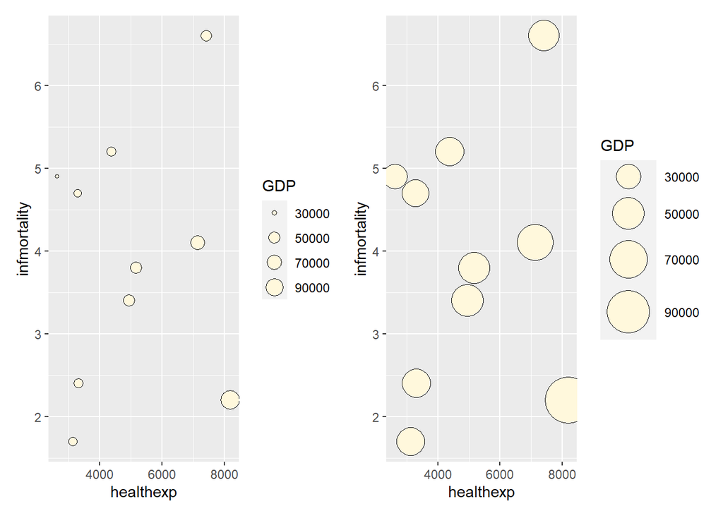

```r
fig534 <-
  cdat %>%
  ggplot(aes(x = healthexp, y = infmortality, size = GDP)) +
  geom_point(shape = 21, color = "#000000", fill = "#FFF8DC")

fig5341 <-
  fig534 +
  scale_size_area(max_size = 15)

fig534 + fig5341
```

또한 ballon plot은 grid위에 categorical한 정보를 표현할 수도 있다.

```r
HairEyeColor
```

```
## , , Sex = Male
##
##        Eye
## Hair    Brown Blue Hazel Green
##   Black    32   11    10     3
##   Brown    53   50    25    15
##   Red      10   10     7     7
##   Blond     3   30     5     8
##
## , , Sex = Female
##
##        Eye
## Hair    Brown Blue Hazel Green
##   Black    36    9     5     2
##   Brown    66   34    29    14
##   Red      16    7     7     7
##   Blond     4   64     5     8
```

```r
hec <-
  HairEyeColor[,,"Male"] + HairEyeColor[,,"Female"]

hec
```

```
##        Eye
## Hair    Brown Blue Hazel Green
##   Black    68   20    15     5
##   Brown   119   84    54    29
##   Red      26   17    14    14
##   Blond     7   94    10    16
```

```r
hec <-
  reshape2::melt(hec, value.name = "count")

hec
```

```
##     Hair   Eye count
## 1  Black Brown    68
## 2  Brown Brown   119
## 3    Red Brown    26
## 4  Blond Brown     7
## 5  Black  Blue    20
## 6  Brown  Blue    84
## 7    Red  Blue    17
## 8  Blond  Blue    94
## 9  Black Hazel    15
## 10 Brown Hazel    54
## 11   Red Hazel    14
## 12 Blond Hazel    10
## 13 Black Green     5
## 14 Brown Green    29
## 15   Red Green    14
## 16 Blond Green    16
```

아래 예제에서 원 아래에 label을 위치시키기 위해 몇 가지 트릭을 사용했다.  
첫번째로 vjust=1로 설정하여 y coordinate와 글자의 위쪽을 맞춘 후, 각 원의 아래에 위치 할 수 있도록 y corrdinate를 계산 값으로 넣었다.

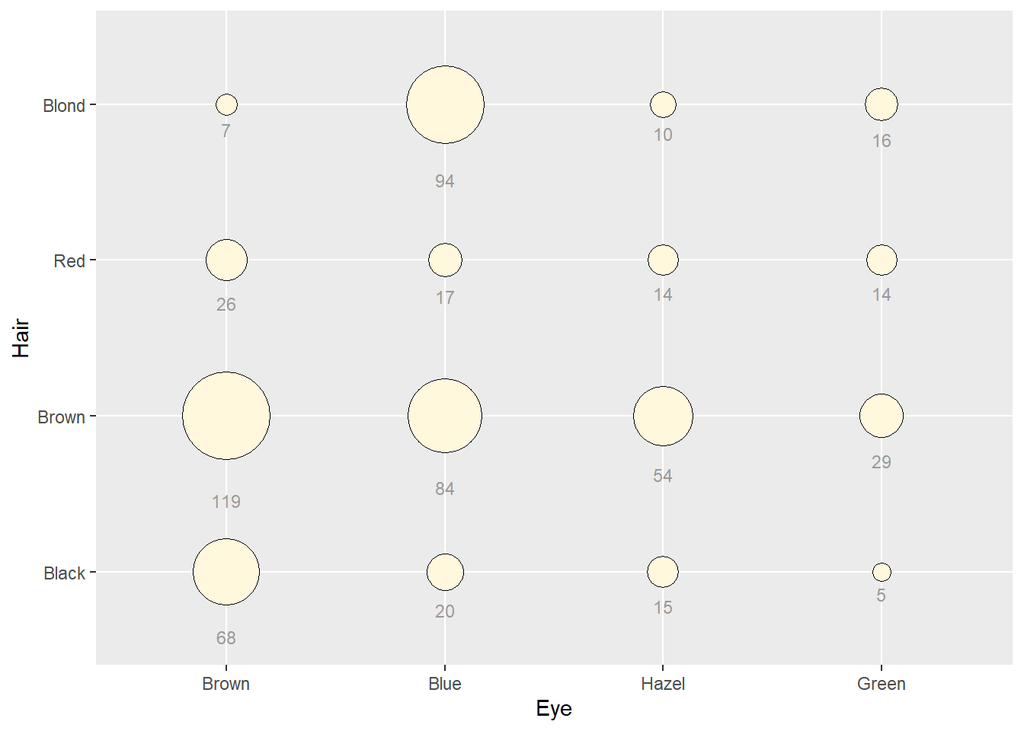

```r
hec %>%
  ggplot(aes(x = Eye, y = Hair)) +
  geom_point(aes(size = count), shape = 21, color = "#000000", fill = "#FFF8DC") +
  scale_size_area(max_size = 20, guide = FALSE) +
  geom_text(aes(y = as.numeric(Hair)-sqrt(count)/22,
                label = count),
            vjust = 1, color = "gray60", size = 3)
```

### 5.13 Making a scatter plot matrix

```r
c2009 <-
  countries %>%
  subset(Year == 2009, select=c(Name, GDP, laborrate, healthexp, infmortality))

c2009
```

```
##                                 Name         GDP laborrate  healthexp
## 50                       Afghanistan          NA      59.8   50.88597
## 101                          Albania   3772.6047      59.5  264.60406
## 152                          Algeria   4022.1989      58.5  267.94653
## 203                   American Samoa          NA        NA         NA
## 254                          Andorra          NA        NA 3089.63589
## 305                           Angola   4068.5757      81.3  203.80787
## 356              Antigua and Barbuda  12501.8666        NA  652.53169
## 407                        Argentina   7665.0734      65.0  730.17301
## 458                          Armenia   2768.6126      66.3  128.85761
## 509                            Aruba          NA        NA         NA
## 560                        Australia  42130.8203      65.2 3867.42853
## 611                          Austria  45555.4345      60.4 5037.31089
## 662                       Azerbaijan   4808.1688      63.0  284.72528
## 713                     Bahamas, The  20916.2842      73.3 1557.65512
```

[output cut: 419 more lines]

scatter matrix를 만드는 가장 쉬운 방법은 `pairs()`를 사용하는 것이다.

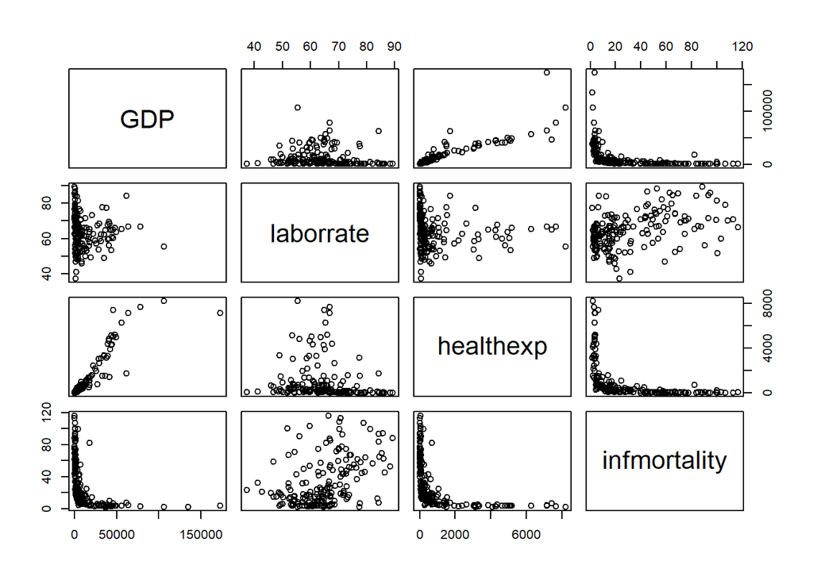

```r
pairs(c2009[,2:5])
```

책에서는 함수를 만들어서 다양한 scatter matrix를 만드는데, 현재는 `GGally` package의 `ggpair()`를 이용하면 손쉽게 다양한 scatter matrix를 만들 수 있다.

```r
library(GGally)
```

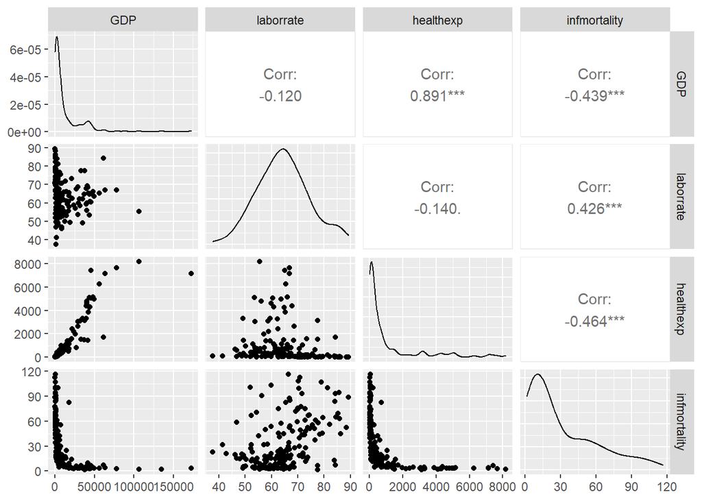

```r
ggpairs(c2009[,2:5])
```

**END**